# Avance informe

Diego Aravena Morales

2021-11-16

# Introducción

En la mayoría de los deportes los competidores hacen uso de estrategias para obtener la victoria. En los deportes colectivos toma un rol vital, tan solo imagine la cantidad de instrucciones que un entrenador les da a sus jugadores por cada partido. La persona encargada de dirigir al equipo debe tomar las mejores decisiones, algo que no es del todo fácil, sin embargo, el paso del tiempo a beneficiado a una gran cantidad de deportes. Un ejemplo claro es el futbol, pues desde que apareció el internet se abrió una fuente llena de posibilidades para el almacenamiento de los datos, dando nombre a lo que probablemente vendría siendo el ícono de esta nueva era, el “Big Data”.

El hecho de que equipos con pocas inversiones en sus jugadores y equipo técnico, hayan logrado salir campeones gracias al uso del Big Data son un claro ejemplo de lo que es capaz esta nueva tecnología. Hoy en día muchos equipos utilizan la estadística para analizar sus partidos, esto con el objetivo de aprender de los datos que provienen de diversas acciones que ocurren durante cada uno ellos. Cualquier hecho relevante que pueda ocurrir durante un partido se considera como un dato y este es almacenado en la nube. El hecho de que algunos de esos datos se suban para todo público en internet, trajo como consecuencia que a muchos fanáticos del fútbol les interese hacer sus propios análisis estadísticos.

Este informe tiene como objetivo conocer y analizar los datos entre las temporadas 2011/2012 y 2016/2017 de la liga de futbol española, la Liga. Mas específicamente nos centraremos en los equipos FC Barcelona y Real Madrid. Además, se quiere analizar un caso particular ocurrido en la liga inglesa, la Premier League. Se hace referencia al equipo inglés Leicester City, el cual obtuvo el primer lugar en la liga inglesa en la temporada 2015-2016, lo que vendría siendo su primera “Premier League” tras 132 años de existencia. La hazaña que realizó fue tal, que el equipo había estado 10 años en otras categorías más bajas, pero logró subir la temporada pasada y luego en la próxima ganar la liga más competitiva a nivel mundial.

Se estudiará cada una de las temporadas de los equipos españoles, esto con el fin de poder identificar patrones, y para el caso del equipo inglés, se analizará la respectiva temporada en la cual sale campeón. A estos tres equipos se le hará una mirada global (comparando con todos los demás equipos) sobre aspectos de los rendimientos de cada uno. Del mismo modo, se estudiarán los comportamientos de los jugadores más importantes para conocerlos más allá de sus habilidades, y así comprender mejor el motivo de su buen desempeño. Estos estudios se organizarán en dos secciones, la primera sección estudiará el comportamiento de los equipos y la segunda el de los jugadores que se decidan analizar.

# Base de datos

La realización de este informe se debe principalmente a la página gratuita [Kaggle](https://www.kaggle.com/) el cual permite acceder a un enorme repositorio de datos publicados por la comunidad. Más especificamente, los datos utilizados son gracias al trabajo realizado por el usuario [*Alin Secareanu*](https://www.kaggle.com/secareanualin/football-events)

Gracias al método de *webscraping* e integrando diferentes fuentes de datos, se pudo obtener este conjunto de datos que proporciona una vista granular de 9.074 juegos, dando un total de 941.009 eventos de las 5 ligas de fútbol europeas más importantes: Inglaterra, España, Alemania, Italia, Francia desde la temporada 2011/2012 hasta la temporada 2016/2017.

Este contiene 3 grandes archivos:

- events.csv: contiene los datos de cada partido. Los comentarios de texto fueron extraídos de: *bbc.com*, *espn.com* y *onefootball.com*
- ginf.csv: contiene metadatos y probabildades de mercado de cada partido. Estos ultimos obtenidos de *oddsportal.com*
- dictionary.txt: diccionario con la descripción de cada variable asignada en cada categoría en el archivo *events.csv*

Todas las categorías están en idioma inglés, incluyendo sus valores, pero para efectos de este trabajo los presentaremos en el idioma español.

# Análisis de equipos

## Leicester city

Partiremos analizando los eventos ocurridos de la Premier League en la temporada 2015-2016, donde el equipo Leicester City se coronó campeón de la liga. Indagaremos sobre el rendimiento que tuvo este equipo comparándolo con el resto de la liga.

Como todo equipo que viene de una categoría más baja, acostumbrarse a la categoría más competitiva que existe no es un reto fácil. Aunque, si bien en la temporada anterior (2014-2015) logró subir a primera categoría, nos interesa ver el progreso que tuvo en esa primera temporada con la siguiente, que es donde finalmente obtiene el primer lugar. Para poner en contexto, la temporada 2014-2015 la Premier League la ganó el Chelsea. En las siguientes dos figuras analizaremos el ratio de goles que tuvo cada equipo en cada una de estas temporadas y veremos si existen algunas semejanzas con el primer lugar.

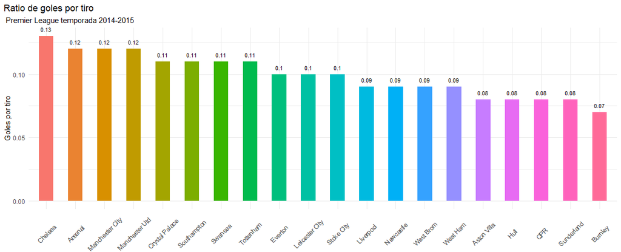

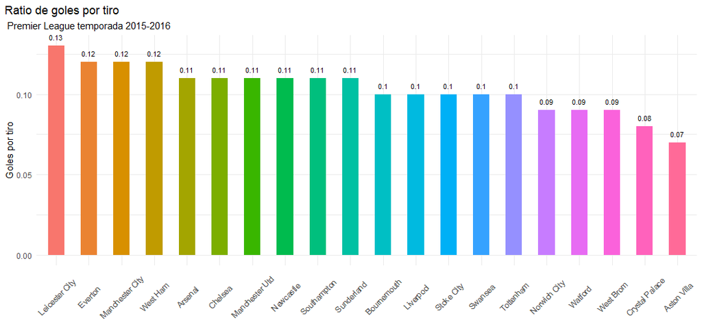

Lo primero que podemos observar es que ambos equipos (Chelsea y Leicester) tienen el mejor ratio de goles por tiro a portería, es decir, por cada tiro al arco que hacen tienen mayor probabilidad de que sea un gol. En ambos casos la probabilidad de marcar un gol dado cualquier intento que se realice es de un 13%. Por otro lado, vemos que nuestro equipo de interés tuvo un enorme progreso, pasando de estar dentro del promedio de goles por tiro entre todos los equipos al equipo con mayor probabilidad de esta categoría.

Yendo por el mismo lado, en las siguientes dos figuras podemos comparar la cantidad de goles por partido entre las dos temporadas.

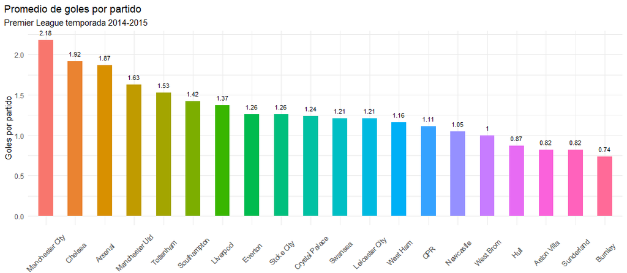

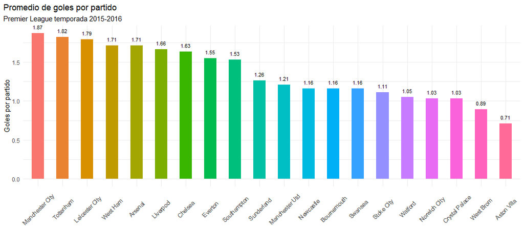

En la temporada 2014-2015, el campeón Chelsea, no era quien tenía el mejor rendimiento en cuanto a goles por partido y lo mismo pasa en la temporada 2015-2016 con el equipo de Leicester City, sin embargo, están dentro del top 3 de los equipos más goleadores. Es interesante también ver que el Manchester City ha estado sobre los demás en las dos temporadas, el cual salió segundo en la temporada 2014-2015 y cuarto en la temporada 2015-2016. Por lo tanto, podemos concluir que el hecho de tener la mayor cantidad de goles por partido no asegura que un equipo pueda salir campeón, pues para eso vale más la precisión de meter un gol por intento.

Ahora, centrándonos solo en la temporada 2015-2016 y en el equipo Leicester City, nos interesa averiguar los distintos comportamientos de los eventos más importantes al momento de marcar goles.

Sabemos que la probabilidad de marcar un gol dado que un jugador simplemente lo intente es de un 13%, pero ahora nos interesa saber cuáles son las probabilidades de marcar un gol dado el sector de la portería al cual se dirige el tiro. Si bien los tiros no siempre se dirigen al arco, en la siguiente figura se presentan estos porcentajes, donde previamente se ha filtrado por todos aquellos tiros que iban dirigidos dentro de la portería independiente si resultaba en gol.

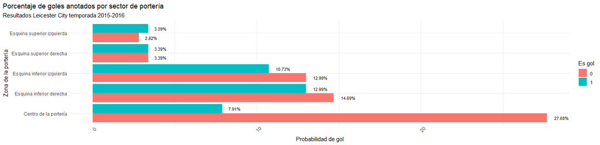

Para entender el gráfico, los colores hacen referencia a 0 si no es gol y 1 si es que lo es, por otro lado los porcentajes están en base al total de tiros realizados hacia las zonas que se indican ahí. Luego, se puede observar claramente que la mayor cantidad de tiros al arco son dirigidos hacia el centro de la portería, siendo un 35.59% de los tiros totales, sin embargo, no es donde más probabilidad hay de marcar un gol, pues el ratio es muy pequeño. En cambio si nos fijamos en los tiros hacia las esquinas inferiores, la probabilidad de marcar un gol aumenta, ya que, al momento de pegarle al balón hacia esas direcciones, la probabilidad de marcar es de casi un 50% respecto de cada zona.

Otro aspecto importante de este hecho es la ubicación de dónde se lanza el balón y las situaciones de juego respectivas, puesto que las probabilidades de marcar un gol son distintas en cada ubicación del campo donde ocurre la jugada. Por este motivo, se creó una tabla que nos presenta el top 10 de cómo se lograron obtener los goles durante la temporada

| Ubicación del campo | Situación del juego | Método de asistencia | Cantidad de goles |
| --- | --- | --- | --- |
| Punto penal | Balón parado | Ninguno | 10 |
| Centro del área | Jugada abierta | Pase | 8 |
| Centro del área | Jugada abierta | Centro | 7 |
| Centro del área | Jugada abierta | Ninguno | 6 |
| Centro del área | Jugada abierta | Pase en profundidad | 5 |
| Centro del área | Balón parado | Centro | 3 |
| Lado izquierdo del área | Jugada abierta | Pase | 3 |
| Rango muy cercano | Jugada abierta | Pase | 3 |
| Centro del área | Balón parado | Pase | 2 |
| Centro del área | Tiro de esquina | Centro | 2 |